# NFL Attendance in 2020

Cason Wight

2023-03-17

## Prep Work for Analysis

### Load all tools and functions

```r
source("utils/eda.R")
source("utils/get_data.R")
```

```
##
##
## Using libcurl 7.84.0 with Schannel
##
##
```

```r
source("utils/mcmc_diagnostics.R")
source("utils/stan.R")
source("models/bayesian.R")
```

[output not shown]

```r
source("results/calculations.R")
source("results/plots.R")
```

### Load data

```r
attendance <- get_attendance_data() %>% mutate(home_team = str_replace(home_team, "Redskins", "Commanders"))
print(attendance %>% head())
```

```
##   X year home_team total_attendance num_games num_games_won prev_attendance
## 1 1 2001     49ers         67469.50        16            12        67745.50
## 2 2 2001     Bears         66944.00        16            13        66944.00
## 3 3 2001   Bengals         56867.25        16             6        58749.00
## 4 4 2001     Bills         63092.00        16             3        70086.88
## 5 5 2001   Broncos         75035.38        16             8        75505.25
## 6 6 2001    Browns         72886.75        16             7        72693.00
##   prev_games_won
## 1              6
## 2              5
## 3              4
## 4              8
## 5             11
## 6              3
```

```r
attendance_2020 <- get_2020_attendance_data() %>% mutate(team_name = str_replace(team_name, "Redskins", "Commanders"))
print(attendance_2020 %>% head())
```

```
##   X          city team_name     Home
## 1 1 San Francisco     49ers    0.000
## 2 2       Chicago     Bears    0.000
## 3 3    Cincinnati   Bengals 4185.312
## 4 4       Buffalo     Bills    0.000
## 5 5        Denver   Broncos 1320.125
## 6 6     Cleveland    Browns 5027.500
```

```r
prices_2019 <- get_average_ticket_price_data()
print(prices_2019 %>% head())
```

```
##   X team_name avg_cost_2019
## 1 1     49ers           178
## 2 2     Bears           376
## 3 3   Bengals           114
## 4 4     Bills           105
## 5 5   Broncos           278
## 6 6    Browns           190
```

```r
team_names <- attendance_2020 %>% pull(team_name) %>% unique() %>% as.character()
print(team_names %>% head())
```

```
## [1] "49ers"   "Bears"   "Bengals" "Bills"   "Broncos" "Browns"
```

```r
team_cities <- sapply(team_names, function(name) attendance_2020 %>% filter(team_name == name) %>% pull(city) %>% .[1])
print(team_cities %>% head())
```

```
##           49ers           Bears         Bengals           Bills         Broncos
## "San Francisco"       "Chicago"    "Cincinnati"       "Buffalo"        "Denver"
##          Browns
##     "Cleveland"
```

```r
rev_data <- get_revenue_data()
print(rev_data %>% head())
```

```
##   Year Total_Revenue Label
## 1 2010          8.35
## 2 2011          8.82
## 3 2012          9.17
## 4 2013          9.58
## 5 2014         11.09
## 6 2015         12.16
```

```r
rev_team_data <- get_team_revenue_data(team_names, team_cities)
print(rev_team_data %>% head())
```

```
##   X year rev team_name  label
## 1 1 2019 492     49ers $492 M
## 2 2 2018 470     49ers
## 3 3 2017 458     49ers
## 4 4 2016 446     49ers
## 5 5 2015 427     49ers
## 6 6 2014 270     49ers
```

### Run models (may take several hours, skip to load models if already done)

```r
fit_samps <- fit_bayesian_mods() %>% save_fit_tight_priors() %>% save_samps_tight_priors() %>% downsample_samps()
```

### Load models (much faster if models have already been run and samples saved, can be skipped if running model in above chunk)

```r
fit_samps <- load_bayesian_samps() %>% downsample_samps()
```

### Load other model metadata

```r
prior <- get_priors()[[1]]
print(prior)
```

```
## $mu_a
## [1] 30000
##
## $sigma_a
## [1] 20000
##
## $mu_b
## [1] 0.7
##
## $sigma_b
## [1] 0.5
##
## $mu_theta
## [1] 1000
##
## $sigma_theta
## [1] 1000
##
## $a_sigma
## [1] 0.4444444
##
## $b_sigma
## [1] 4.444444e-05
##
## $lambda
## [1] 8000
##
## $eta
## [1] 0.1
```

```r
var_names <- fit_samps %>% names() %>% .[1:6]
print(var_names)
```

```
## [1] "overall_alpha" "overall_beta"  "theta"         "sigma"
## [5] "alphas"        "betas"
```

Model:
$$\begin{align}
\text{Est 2020
Attendance}_\text{team}&\sim\mathcal{N}\left(\mu_\text{team},
\sigma^2\right) \\
\mu_\text{team}&=\alpha_\text{team} \\
&~~~~~~+\beta_\text{team} \times \text{2019 Year Attendance}
\\
&~~~~~~+\theta \times \text{2019 Num Games Won} \\
\sigma&\sim\text{Gamma}(\alpha_\sigma, \beta_\sigma) \\
\alpha_\text{team}&\sim\mathcal{N}(\alpha, \lambda^2) \\
\alpha&\sim\mathcal{N}(\mu_{\alpha}, \sigma^2_\alpha) \\
\beta_\text{team}&\sim\mathcal{N}(\beta, \eta^2) \\
\beta&\sim\mathcal{N}(\mu_{\beta}, \sigma^2_\beta) \\
\theta&\sim\mathcal{N}(\mu_{\theta}, \sigma^2_\theta) \\
\end{align}$$

## Exploratory Data Analysis

### Who has the most attendees at their home games?

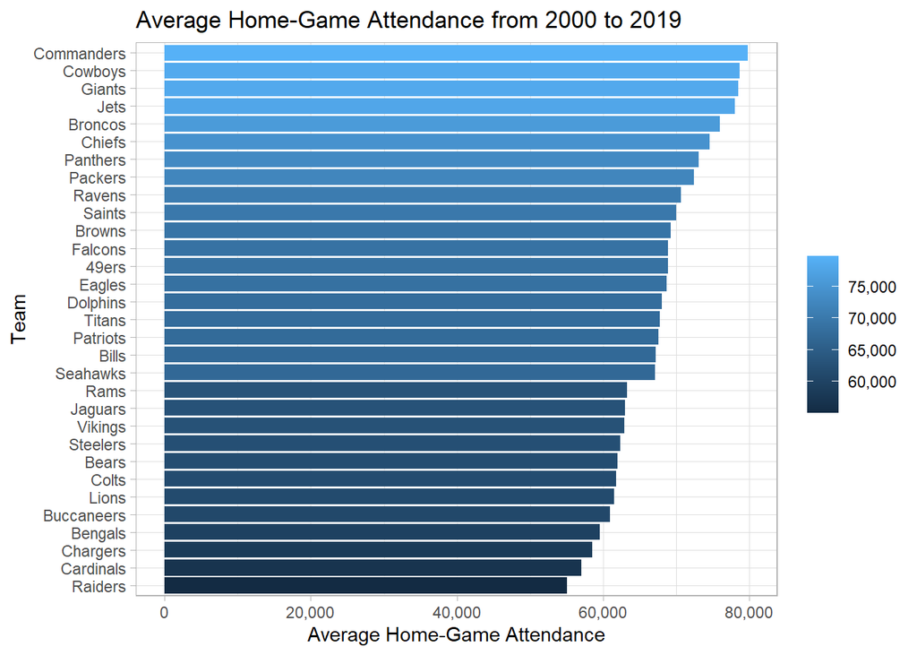

```r
plot_avg_attendance_all_years(attendance, "All teams")
```

Commanders, Cowboys, and Giants have the highest attendance. Raiders, Cardinals, and Chargers have the lowest.

### Who wins the most?

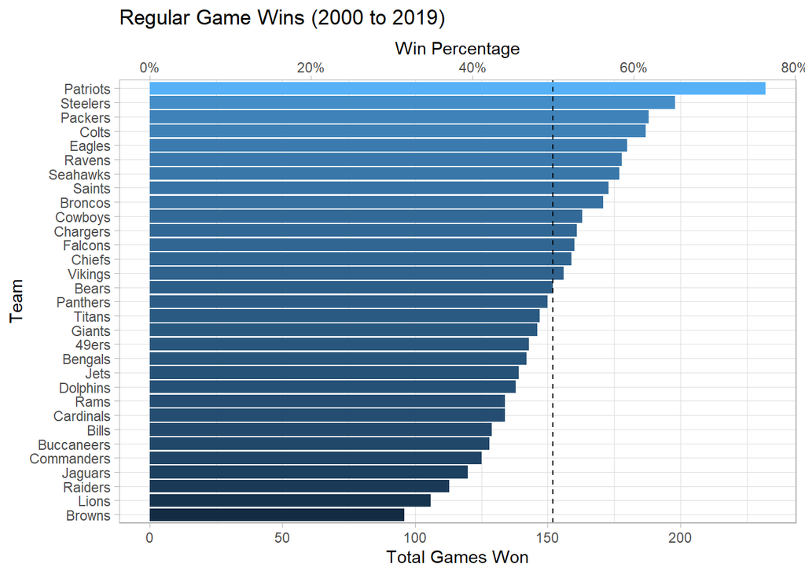

```r
plot_avg_win_rate_all_years(attendance, "All teams")
```

Patriots, Steelers, and Packers win the most. Browns, Lions, and Raiders lose the most.

# How much money does the NFL make?

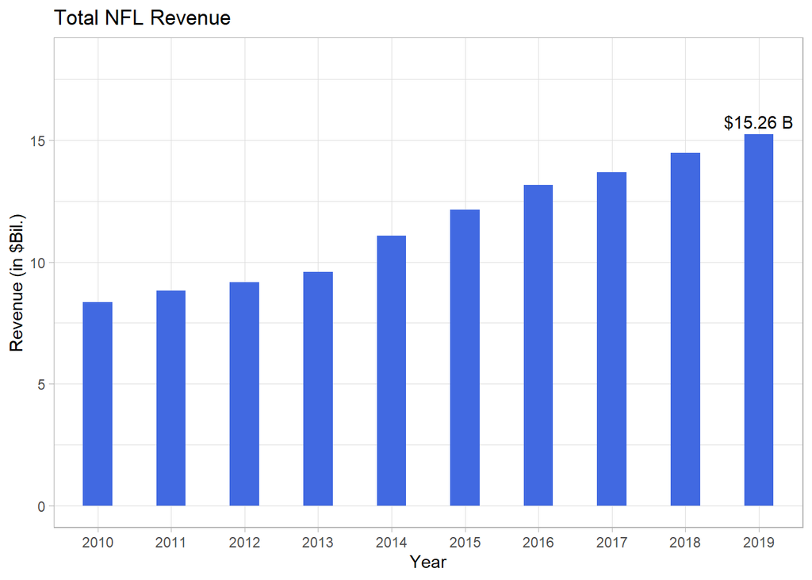

```r
plot_yearly_revenue(rev_data, rev_team_data, "All teams")
```

There is a roughly linear trend, increasing by about $1B every year. In 2019, NFL revenue totaled $15.26B.

## Parameter modeling

### What is the prior and posterior predicted distribution of the parameters?

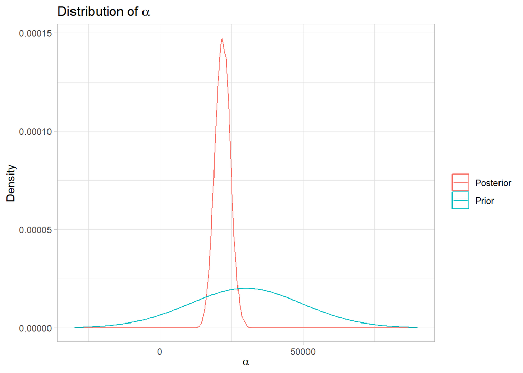

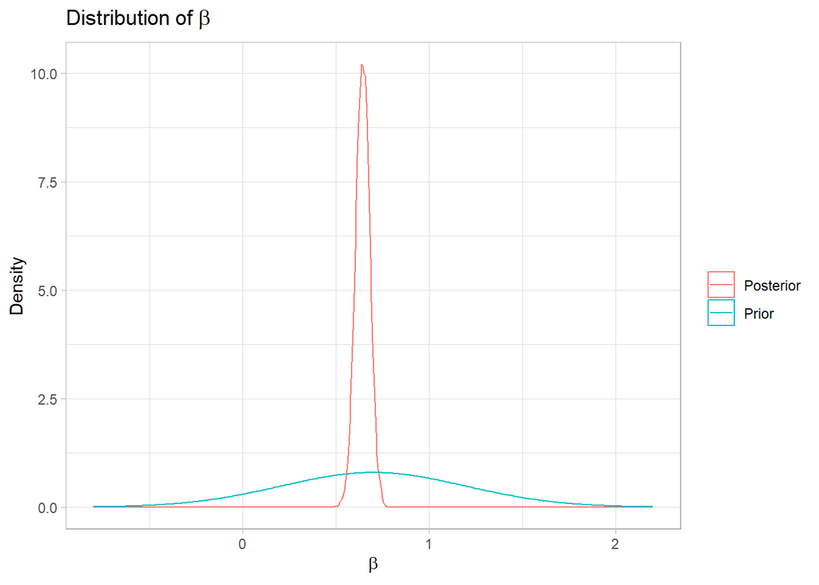

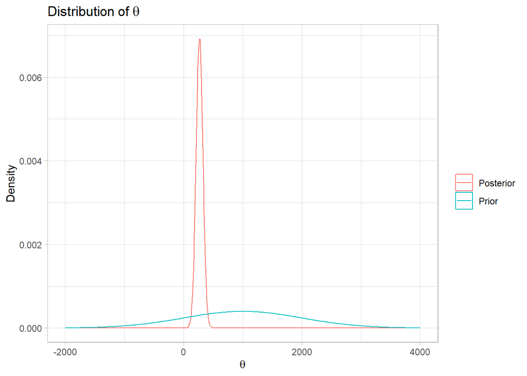

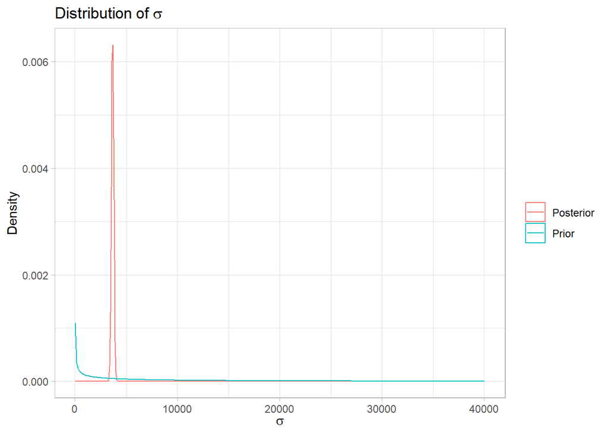

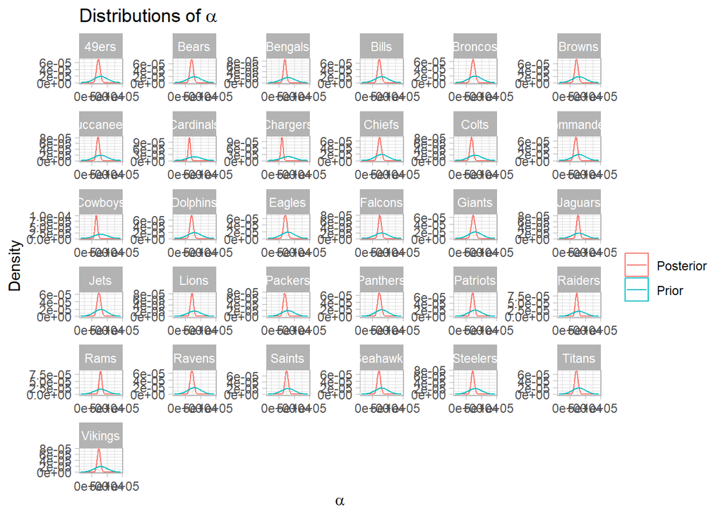

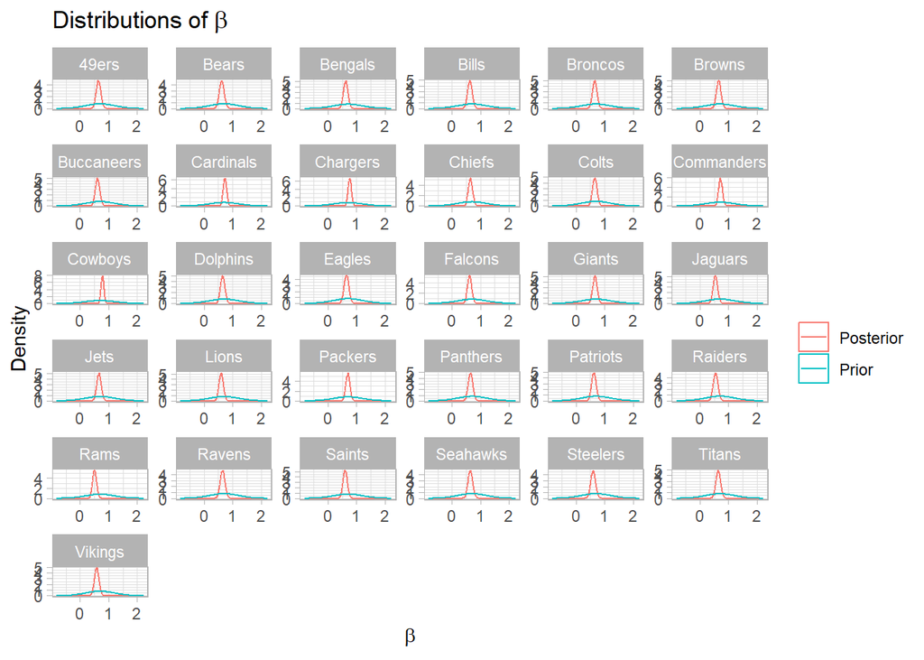

```r
for (var in c("overall_alpha", "overall_beta", "theta", "sigma", "alphas", "betas")){
  plt <- plot_distribution(fit_samps, prior, var, team_names, "All teams")
  print(plt)
}
```

### Do the MCMC diagnoistics look healthy (was this a good fit)?

```
## [1] "overall_alpha"
## [1] "Effective sample size:"
## overall_alpha
##      9213.433
## [1] "Gelman statistic:"
## overall_alpha
##      1.000232
```

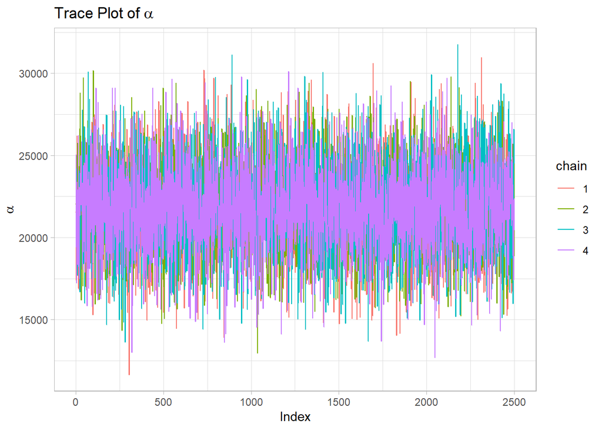

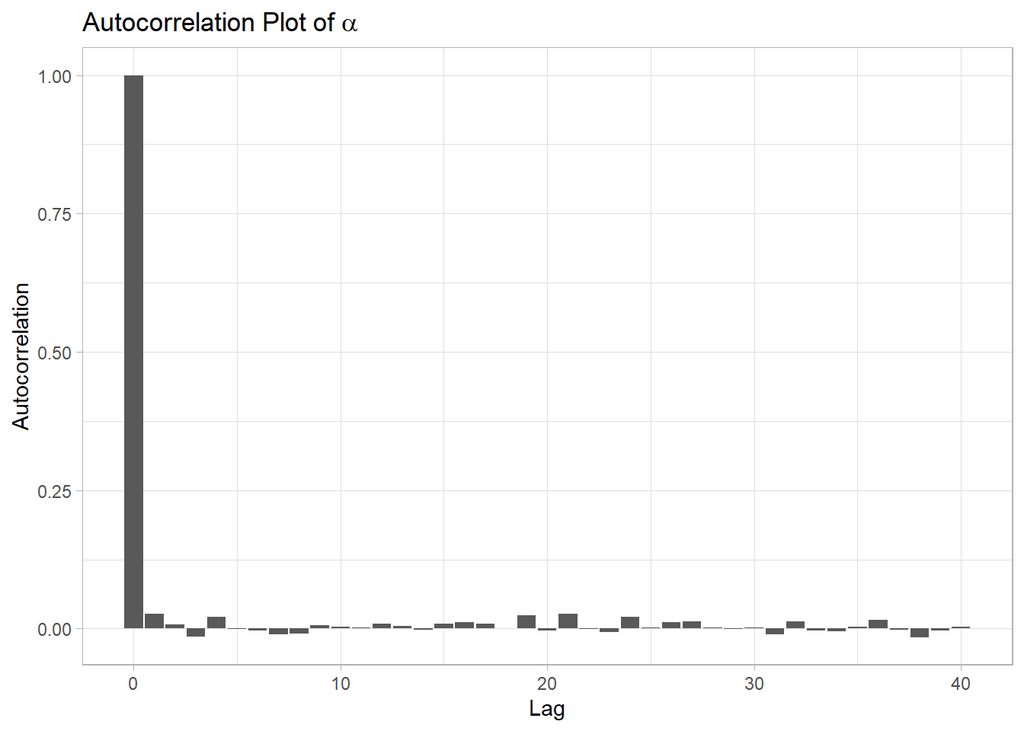

```
## [1] ""
## [1] "overall_beta"
## [1] "Effective sample size:"
## overall_beta
##        10000
## [1] "Gelman statistic:"
## overall_beta
##     1.000341
```

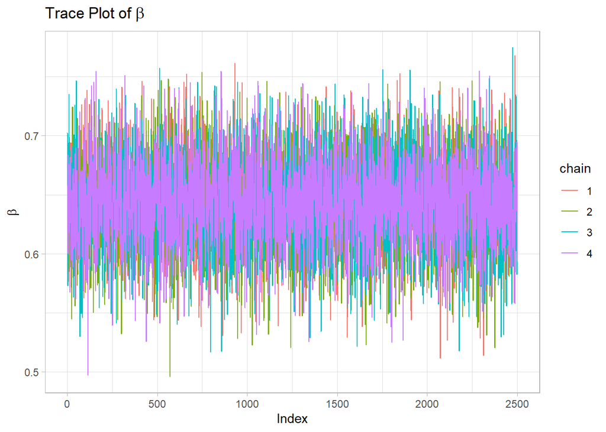

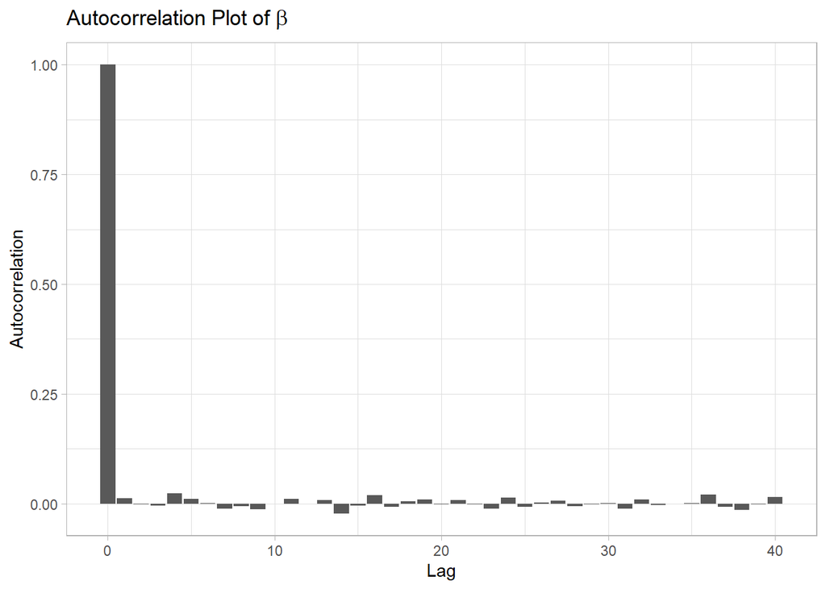

```
## [1] ""
## [1] "theta"
## [1] "Effective sample size:"
## theta
## 10000
## [1] "Gelman statistic:"
##    theta
## 1.000573
```

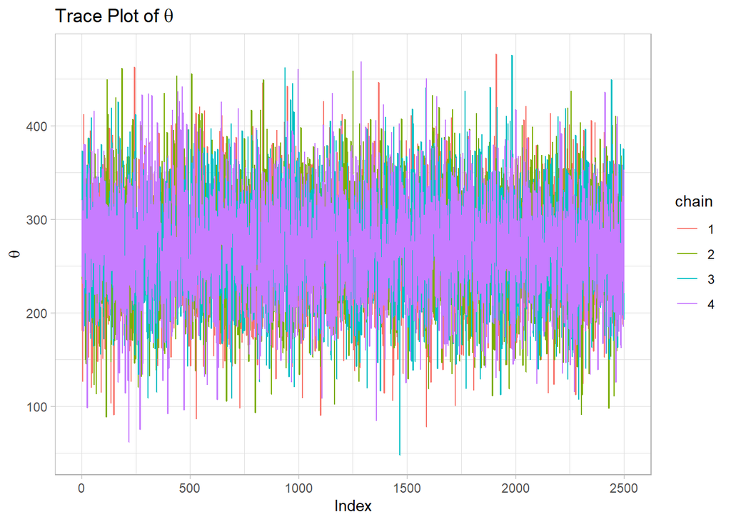

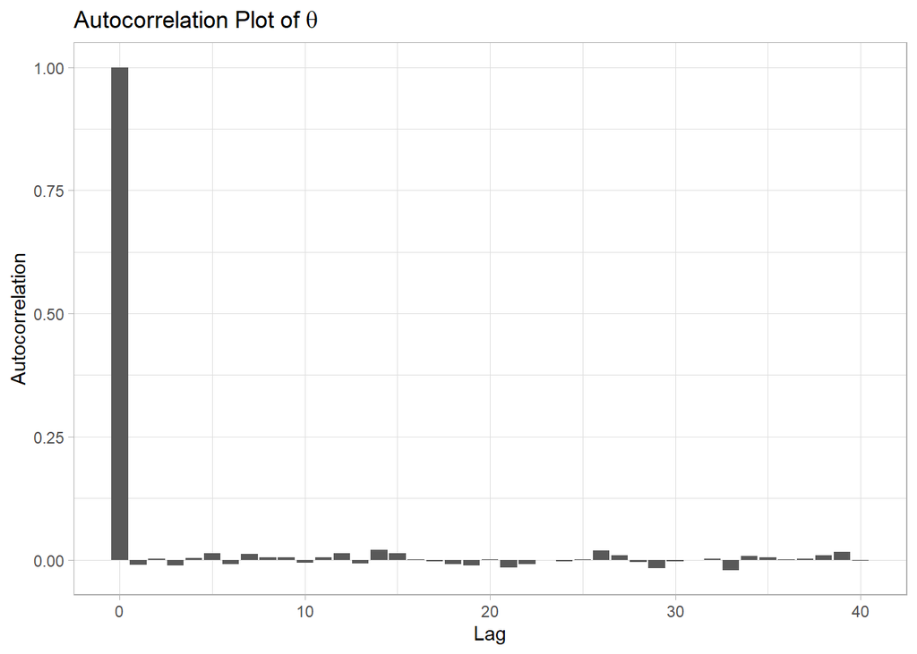

```
## [1] ""
## [1] "sigma"
## [1] "Effective sample size:"
## sigma
## 10000
## [1] "Gelman statistic:"
##     sigma
## 0.9998749
```

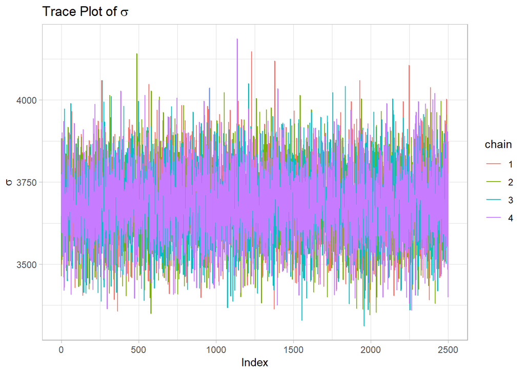

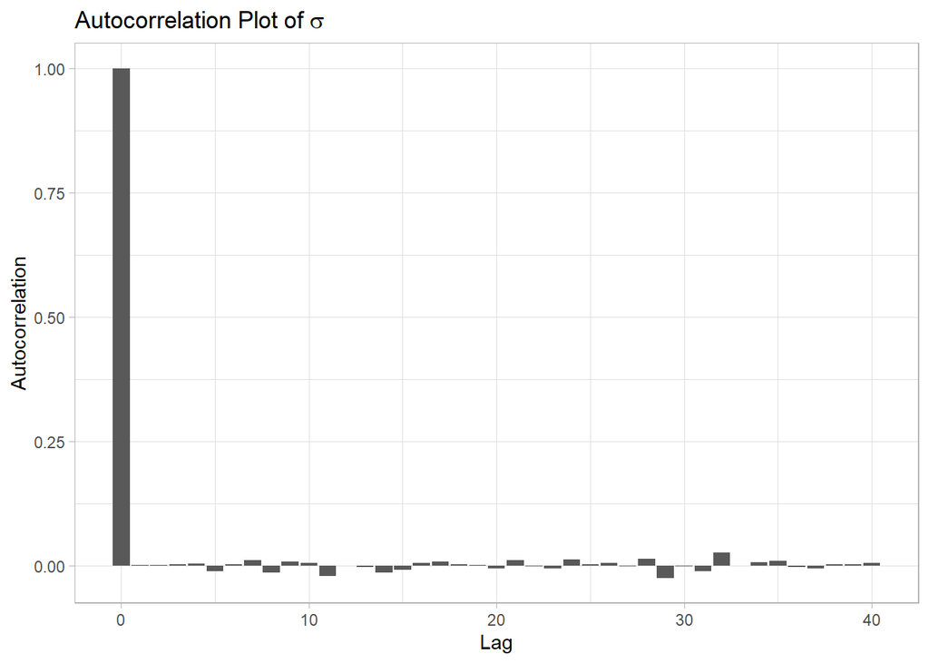

```
## [1] ""
## [1] "alphas"
## [1] "Effective sample size:"
##      alpha_49ers      alpha_Bears    alpha_Bengals      alpha_Bills
##         9463.464        10000.000         9549.997        10000.000
##    alpha_Broncos     alpha_Browns alpha_Buccaneers  alpha_Cardinals
##        10000.000        10000.000        10000.000        12066.402
##   alpha_Chargers     alpha_Chiefs      alpha_Colts    alpha_Cowboys
##        10000.000        10000.000        10000.000        10000.000
##   alpha_Dolphins     alpha_Eagles    alpha_Falcons     alpha_Giants
##        10000.000        10000.000        11522.932        10000.000
##    alpha_Jaguars       alpha_Jets      alpha_Lions    alpha_Packers
##        10000.000        10000.000        10000.000        10000.000
##   alpha_Panthers   alpha_Patriots    alpha_Raiders       alpha_Rams
##        10000.000        11776.173        10000.000        10000.000
##     alpha_Ravens alpha_Commanders     alpha_Saints   alpha_Seahawks
##        10000.000        10000.000        10000.000        10000.000
##   alpha_Steelers     alpha_Titans    alpha_Vikings
##        10000.000        10000.000        10000.000
## [1] "Gelman statistic:"
##      alpha_49ers      alpha_Bears    alpha_Bengals      alpha_Bills
##        1.0001676        1.0002543        1.0000868        0.9998865
##    alpha_Broncos     alpha_Browns alpha_Buccaneers  alpha_Cardinals
##        0.9999070        0.9999875        1.0001289        0.9997921
##   alpha_Chargers     alpha_Chiefs      alpha_Colts    alpha_Cowboys
##        0.9999130        1.0001615        1.0000029        1.0001343
##   alpha_Dolphins     alpha_Eagles    alpha_Falcons     alpha_Giants
##        0.9999557        0.9997674        0.9998492        1.0007011
##    alpha_Jaguars       alpha_Jets      alpha_Lions    alpha_Packers
##        0.9998726        0.9999662        1.0008359        1.0001010
##   alpha_Panthers   alpha_Patriots    alpha_Raiders       alpha_Rams
##        1.0000661        1.0000305        0.9999694        1.0007546
##     alpha_Ravens alpha_Commanders     alpha_Saints   alpha_Seahawks
##        1.0000433        1.0000755        1.0000628        1.0002320
##   alpha_Steelers     alpha_Titans    alpha_Vikings
##        0.9999465        1.0004003        0.9999348
```

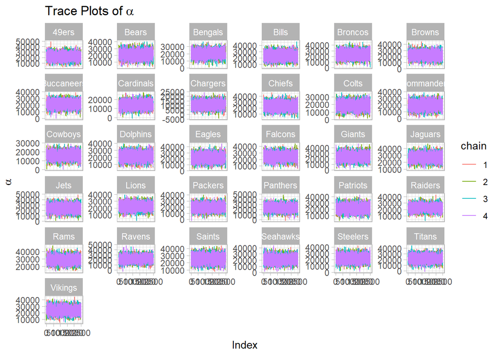

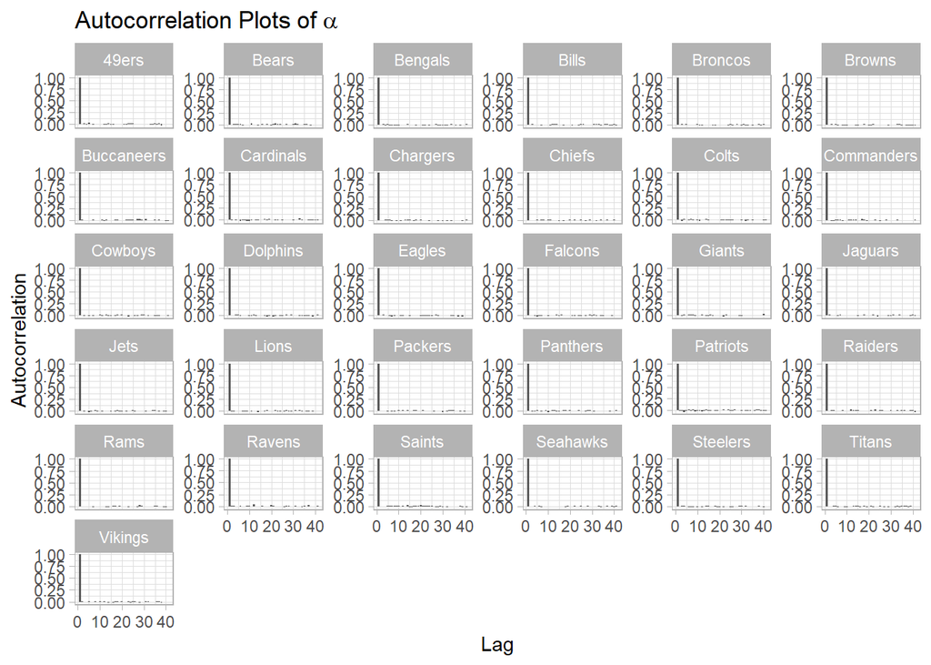

```
## [1] ""
## [1] "betas"
## [1] "Effective sample size:"
##      beta_49ers      beta_Bears    beta_Bengals      beta_Bills    beta_Broncos
##        9583.035        9389.456        9523.931       10000.000       10000.000
##     beta_Browns beta_Buccaneers  beta_Cardinals   beta_Chargers     beta_Chiefs
##       10000.000       10000.000       10000.000       10000.000       10000.000
##      beta_Colts    beta_Cowboys   beta_Dolphins     beta_Eagles    beta_Falcons
##       10000.000       10000.000        9080.621       10000.000       10000.000
##     beta_Giants    beta_Jaguars       beta_Jets      beta_Lions    beta_Packers
##       10000.000       10000.000       10000.000       10000.000       10000.000
##   beta_Panthers   beta_Patriots    beta_Raiders       beta_Rams     beta_Ravens
##       10000.000       11847.488       10000.000       10000.000       10000.000
## beta_Commanders     beta_Saints   beta_Seahawks   beta_Steelers     beta_Titans
##       10000.000       10000.000       10000.000       10000.000       10000.000
##    beta_Vikings
##       10000.000
## [1] "Gelman statistic:"
##      beta_49ers      beta_Bears    beta_Bengals      beta_Bills    beta_Broncos
##       1.0001175       1.0002430       0.9999911       0.9999017       0.9999981
##     beta_Browns beta_Buccaneers  beta_Cardinals   beta_Chargers     beta_Chiefs
##       1.0000713       1.0001042       0.9999691       0.9999648       1.0000203
##      beta_Colts    beta_Cowboys   beta_Dolphins     beta_Eagles    beta_Falcons
##       1.0000109       1.0000742       0.9999483       0.9997532       0.9998723
##     beta_Giants    beta_Jaguars       beta_Jets      beta_Lions    beta_Packers
##       1.0005091       0.9999620       0.9999679       1.0008697       1.0001320
##   beta_Panthers   beta_Patriots    beta_Raiders       beta_Rams     beta_Ravens
##       1.0000080       1.0001298       0.9999353       1.0006219       1.0000081
## beta_Commanders     beta_Saints   beta_Seahawks   beta_Steelers     beta_Titans
##       1.0000573       1.0000465       1.0001737       0.9999748       1.0004784
##    beta_Vikings
##       0.9998656
```

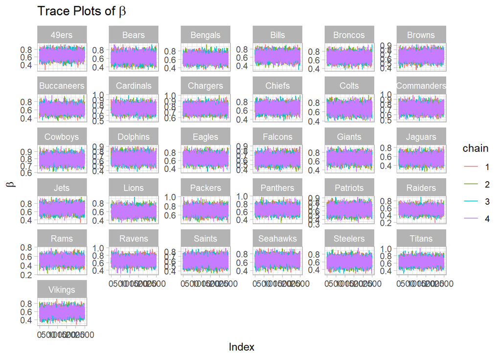

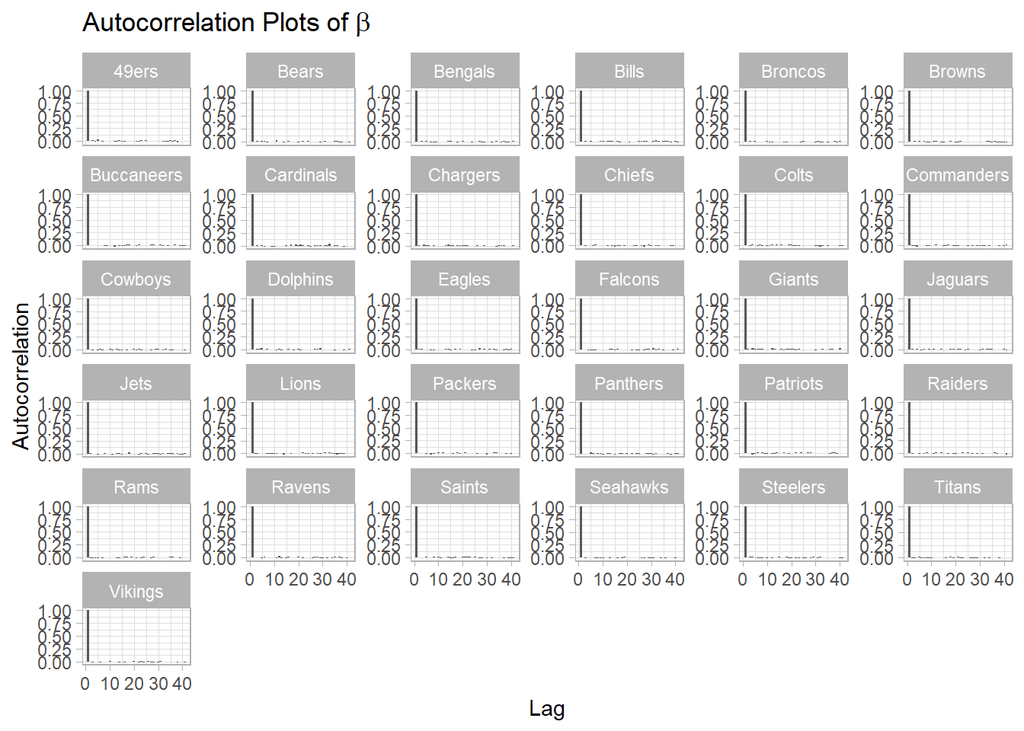

```
## [1] ""
```

```r
for (var in c("overall_alpha", "overall_beta", "theta", "sigma", "alphas", "betas")) {
  neff <- get_effective_sample_size(fit_samps, var, team_names, team_name="All teams")
  rhat <- get_rhat(fit_samps, var, team_names, team_name="All teams")
  trace_plt <- get_trace_plot(fit_samps, var, team_names, team_name="All teams")
  acf_plt <- get_acf_plot(fit_samps, var, team_names, team_name="All teams")

  print(var)
  print("Effective sample size:")
  print(neff)
  print("Gelman statistic:")
  print(rhat)
  print(trace_plt)
  print(acf_plt)
  print("")
}
```

Fit looks great. Effective sample size is roughly 10,000 for all parameters. The Gelman statistic is roughly 1.00 for all parameters. Nothing concerning is in the trace plots nor the autocorrelation plots.

## Estimated Revenue Loss

Which teams had the biggest attendance loss because of covid?

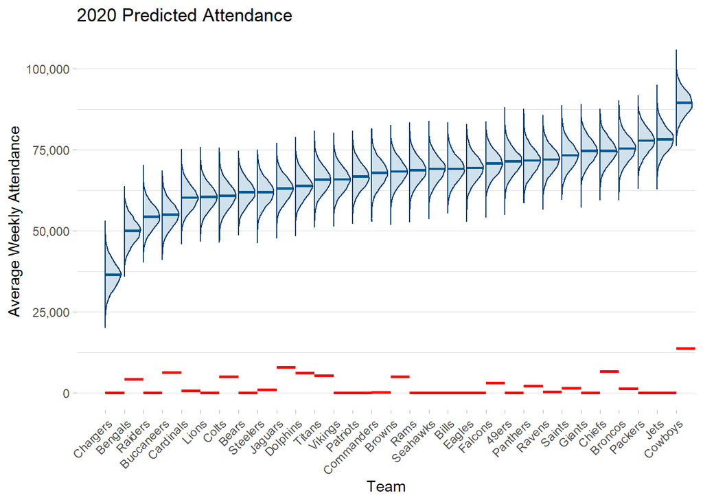

```r
post_predicted_attendance <- get_post_predicted_attendance(attendance, fit_samps, team_names, "All teams")
plot_attendance(post_predicted_attendance, attendance_2020, team_names, "All teams")
```

The Jets seem to have the worst impact on attendance. The Chargers had the smallest impact, becuase they had such low attendance in the first place.

$$\text{Impact of Covid on Weekly
Attendance}_\text{team}\approx\text{Actual 2020
Attendance}_\text{team}-\text{Est 2020 Attendance}_\text{team}$$
$$\text{Est Revenue
Impact}\approx\sum_{\text{team}\in\text{All teams}}{\text{Impact of
Covid on Weekly Attendance}_\text{team} \times \text{Avg. 2019 Ticket
Cost}_\text{team} \times \text{Num Weeks}}$$

How much money was actually lost on ticket sales because of covid?

```r
post_predicted_loss_attendance <- get_post_predicted_lost_attendance(post_predicted_attendance, attendance_2020, team_names, "All teams")
print(post_predicted_loss_attendance %>% head())
```

```
##   pred_attendance team_name X          city     Home      diff
## 1        71425.05     49ers 1 San Francisco    0.000 -71425.05
## 2        61881.81     Bears 2       Chicago    0.000 -61881.81
## 3        49920.33   Bengals 3    Cincinnati 4185.312 -45735.02
## 4        69043.25     Bills 4       Buffalo    0.000 -69043.25
## 5        75368.74   Broncos 5        Denver 1320.125 -74048.61
## 6        68245.86    Browns 6     Cleveland 5027.500 -63218.36
```

```r
est_rev_loss <- get_est_lost_rev(post_predicted_loss_attendance, prices_2019, "All teams")
```

Estimated Revenue Loss: ‒$6.13B